# pipeline

Soohyun Kim, Xinyao Wu, Yuxin Yang

5/01/2019

# Breast Cancer Diagnosis

## Data Preprocessing

```r
dat.original <- read_csv("./data/breastcancer.csv")
dat <- dat.original %>%
  select(-c(id,X33))

dat$diagnosis <- ifelse(dat$diagnosis == "M", 1, 0)

#summary(dat)
```

Notice that the ranges of the features vary greatly. Here, we normalize the data so that features with different scales do not dominate over others and so we can compare the features.

```r
# x is a feature variable
normalize <- function(x) {
  return((x - mean(x)) / sd(x))
}

# normalize all features
dat.norm <- as.data.frame(lapply(dat[,2:31], normalize))
dat.norm <- cbind(dat$diagnosis, dat.norm)
names(dat.norm)[1] <- "diagnosis"

#summary(dat.norm)
```

Now, with the normalized data, we will drop features that show high correlation, with cutoff 0.85. Doing so will not affect results.

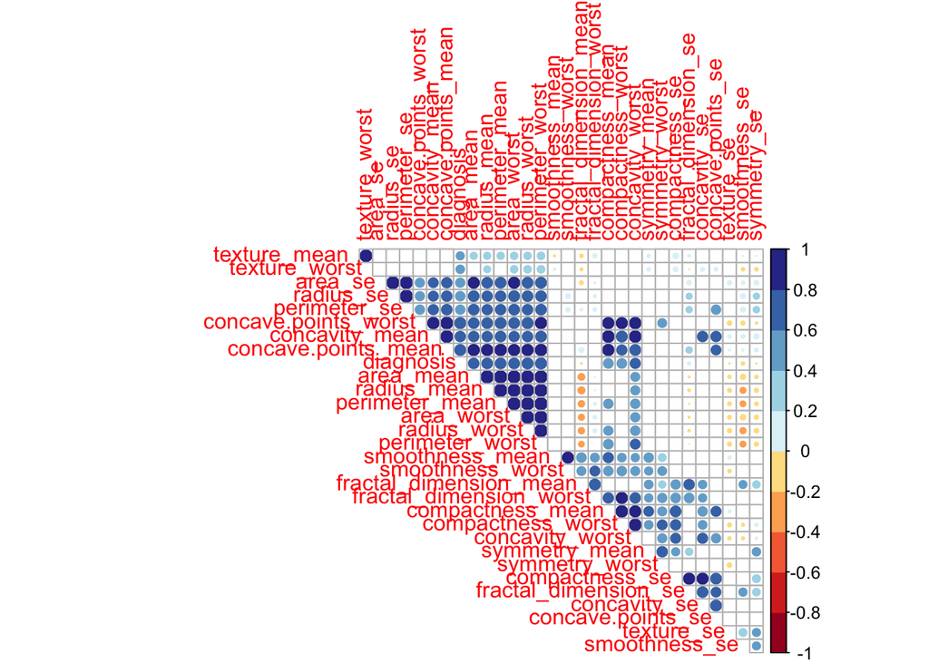

```r
corr <- cor(dat.norm)
# identify highly correlated covariates
highCorr <- findCorrelation(corr, cutoff = 0.85, exact = TRUE)
highCorr.names <- findCorrelation(corr, cutoff = 0.85, exact = TRUE,  names = TRUE)
# remove one of two highly correlated features
dat.norm.use <- dat.norm[,-c(highCorr)]

p.mat <- cor.mtest(corr)$p
corrplot(corr, method="circle",
         order = "hclust",
         type = "upper",
         p.mat = p.mat,
         sig.level = 0.05,
         insig = "blank",
         diag = FALSE,
         col = brewer.pal(n = 10, name = "RdYlBu"))
```

The features dropped from analysis (high correlation cutoff = 0.85) are: concavity_mean, concave.points_mean, concave.points_worst, compactness_mean, concavity_worst, perimeter_worst, radius_worst, perimeter_mean, area_worst, radius_mean, perimeter_se, radius_se, texture_mean. There are now 17 features after feature selection.

## Full Logistic Model

A logistic regression model with all variables does not converge. Furthermore, we have seen from the correlation plot that multicollinearity exists between many of the covariates. We fit a “full” logistic model using the remaining 17 variables after feature selection based on a between-features correlation threshold of 0.85.

```r
# Split the data into training and test set
training.samples <- dat.norm.use$diagnosis %>%
  createDataPartition(p = 0.8, list = FALSE)
dat.train  <- dat.norm.use[training.samples, ]
dat.test <- dat.norm.use[-training.samples, ]

# Fit "full" model
full.model <- glm(diagnosis ~ .,
                   data = dat.train, family = "binomial")

full.coef <- knitr::kable(full.model$coef); full.coef
```

|  | x |
| --- | --- |
| (Intercept) | 2.6630942 |
| area_mean | 1.6801675 |
| smoothness_mean | 0.2660282 |
| symmetry_mean | -0.3554985 |
| fractal_dimension_mean | -0.1454344 |
| texture_se | -2.5716137 |
| area_se | 20.6017938 |
| smoothness_se | 0.1518252 |
| compactness_se | -0.1646631 |
| concavity_se | 0.2613843 |
| concave.points_se | 3.3161136 |
| symmetry_se | -1.1932438 |
| fractal_dimension_se | -5.5019334 |
| texture_worst | 3.8513985 |
| smoothness_worst | 1.2537625 |
| compactness_worst | -0.2286985 |
| symmetry_worst | 1.8014691 |
| fractal_dimension_worst | 3.7280580 |

```r
# Make predictions
prob <- full.model %>% predict(newdata = dat.test, type = "response")
pred.classes <- ifelse(prob > 0.5, "M", "B")

# Model accuracy
n = length(dat.test$diagnosis)
obs.classes <- ifelse(dat.test$diagnosis == 1, "M", "B")
mean(pred.classes == obs.classes) ## prediction accuracy
```

```
## [1] 0.9469027
```

```r
RSE1 = mean((prob - dat.test$diagnosis)^2)
aRSE1 = RSE1*n/(n-2*length(full.model$coef))
```

## Full Model: Likelihood, Gradient, Hessian

$$P(Y_i = 1 | X_i = x_i) = \frac{exp(\beta_0 + X_i^T\beta)}{1+exp(\beta_0 + X_i^T\beta)}$$

For our model, the likelihood function $L(\beta_0, \beta; Y)$ is

$$L(\beta) = \prod_{i=1}^{n}p(x_i)^{y_i}(1-p(x_i))^{1-y_i}$$

For our model, the log-likelihood function $l(\beta_0, \beta; Y)$ is

$$l(\beta_0, \beta) = \sum_{i=1}^{n}[Y_i(\beta_0 + X_i^T\beta) - log(1+exp(\beta_0 + X_i^T\beta))]$$
We get gradient and Hessian from the log-likelihood of of our logistic regression model

```r
hess <- function(x, p){
  hess = matrix(0, ncol(x), ncol(x))
  for (i in 1:nrow(x)){
    a <- x[i,] %*% t(x[i,]) * p[i] *(1 - p[i])
    hess <- hess +a
  }
  return(-hess)
}
```

## Newton Raphson

```r
logisticstuff <- function(x,y, betavec){
  u <- x %*% betavec
  expu <- exp(u)
  ## create loglike for large p
  loglik <- vector(nrow(x), mode = "numeric")
  for(i in 1:nrow(x))
    loglik[i] <- y[i]*u[i] - log(1+expu[i])
  ## log-likelihood at betavec
  loglik <- sum(loglik)
  p <- expu / (1+expu)
  ## P(Y_i = 1 | x_i)
  grad <- vector(length(betavec), mode = "numeric")
  ## gradient at betavec
  for(i in 1:18)
    grad[i] <- sum(t(x[,i]) %*% (y - p))
  ## function for hess due to large p value
  Hess <- hess(x , p)
  return(list(loglik = loglik, grad = grad, Hess = Hess))
}
```

```r
NewtonRaphson <- function(x, y, func, start, maxiter = 15, tol = 1e-5) {
  i <- 0
  cur <- start
  stuff<- func(x,y, cur)
  res <- c(0, cur)
  prevloglik <- -Inf
  while(i < maxiter && abs(stuff$loglik - prevloglik) > tol){
    i <- i+1
    prevloglik <- stuff$loglik
    prev <- cur
    cur <- prev - solve(stuff$Hess) %*% stuff$grad
    stuff <- func(x,y, cur)
    res <- rbind(res,c(i,cur))
  }
  return(res)
}
```

```r
## find parameter with possible data
beta = rep(0.001, 18)
Y = as.vector(dat.train$diagnosis)
intercept = rep(1,nrow(dat.train))
X = dat.train[,2:18] %>%
  cbind(intercept,.) %>%
  as.matrix()
newton = NewtonRaphson(X,Y,
                       logisticstuff,
                       beta,
                       maxiter = 15)

param.estimates <- tail(as.matrix(newton[,-1]),1) # these match with glm results
param.estimates
```

```
##      [,1]     [,2]      [,3]       [,4]       [,5]      [,6]     [,7]      [,8]
##  2.663094 1.680167 0.2660282 -0.3554985 -0.1454344 -2.571614 20.60179 0.1518252
##        [,9]     [,10]    [,11]     [,12]     [,13]    [,14]    [,15]      [,16]
##  -0.1646632 0.2613843 3.316114 -1.193244 -5.501933 3.851398 1.253762 -0.2286985
##     [,17]    [,18]
##  1.801469 3.728058
```

## Logistic-LASSO, Coordinate-Wise Update

```r
Y = as.vector(dat.train$diagnosis)
X = dat.train[,-1] %>% as.matrix()


# functions updating objective function
  ## probability evalutated at current parameters
  func.cur.p <- function(beta0, beta, x){
    intercept = rep(1,nrow(x))
    u <-  intercept * beta0 + x %*% beta
    expu <- exp(u)
    p <- expu / (1 + expu)
    return(list(u = u, expu = expu, p = p))
  }

  ## working weights
  func.weights <- function(p){
    w <- p*(1-p)
    return(w)
  }

  ## working response
  func.resp <- function(u, y, p){
    z <- u + ((y - p)/(p*(1-p)))
    return(z)
  }

  ## objective function: penalized weighted least-squares

  func.obj <- function(u, x, w, z, lambda, beta){
    l_Q <- ((1/2)*nrow(x)*sum(t(w)%*%(z - u)^2)) + lambda*sum(abs(beta))

    return(l_Q)
  }

# functions for updating parameters using coordinate descent alg.
  ## soft-threshold function

  func.soft <- function(beta, gamma){

    beta.lasso <- as.numeric()

    if (beta > 0 && gamma < abs(beta)){
      beta.lasso <- beta - gamma
    }
    else if (beta < 0 && gamma < abs(beta)){
      beta.lasso <- beta + gamma
    }
    else{
      beta.lasso <- 0
    }
    return(beta.lasso)
  }
```

```r
# x: variables matrix (does not include vector of 1's for intercept)
# y: binary response variable (malignant vs. benign)
# beta: starting values of beta parameters
# lambda: penalty on l1 regularization

func.logLasso.cd <- function(x, y, beta, lambda, tol = 10e-6, maxiter = 1000){

  # Initialize parameters
  beta0 <- 1/length(y) * sum(y - x %*% beta)

  cur.p <- func.cur.p(beta0 = beta0, beta = beta, x = x)
  cur.w <- func.weights(p = cur.p$p)
  cur.z <- func.resp(u = cur.p$u,
                       y = y,
                       p = cur.p$p)

  # Quadratic approx. of loglik at starting beta values
  l_Q <- func.obj(u = cur.p$u,
                    x = x,
                    w = cur.w,
                    z = cur.z,
                    lambda = lambda,
                    beta = beta)
  i <- 0
  track.param <- c(iter = 0, l_Q, beta0,beta)

  # Updating parameters
  while (i < maxiter && l_Q > tol) {

    i = i + 1

    for (j in 1:length(beta)) {

      # Run coordinate descent algorithm on penalized weighted-LS to update betas
      r <- y - (x %*% beta) # current residual
      y.diff <- r + (x[,j] * beta[j])
      weighted.beta <- sum(cur.w * x[,j] * y.diff)
      # update betas
      beta[j] <- func.soft(beta = weighted.beta, gamma = lambda)/ sum(cur.w * x[,j]^2)
    }

    track.param <- rbind(track.param, c(iter = i, l_Q, beta0, beta))

    # Update quadratic approx. of loglik using updated parameters
    beta0 <- mean(y) - sum(colMeans(x) * beta)
    cur.p <- func.cur.p(beta0 = beta0, beta = beta, x = x)
    cur.w <- func.weights(p = cur.p$p)
    cur.z <- func.resp(u = cur.p$u,
                       y = y,
                       p = cur.p$p)
    l_Q <- func.obj(u = cur.p$u,
                    x = X,
                    w = cur.w,
                    z = cur.z,
                    lambda = lambda,
                    beta = beta)


  }

  track.param <- as.data.frame(track.param)
  names(track.param) <- c("iter", "approx_loglik", "intercept", colnames(X))

  final.coef <- tail(track.param[,-c(1:2)], 1)
  return(final.coef)
}

# Try lambda = e^(1/2)
#func.logLasso.cd(x = X, y = Y, beta = rep(0, ncol(X)), exp(.5))
```

```r
grid.lambda <- exp(seq(from = 5, to = -5, by = -0.25))

res <- func.logLasso.cd(x = X, y = Y, beta = rep(0, ncol(X)), grid.lambda[1])

for (i in 2:length(grid.lambda)) {
  res <- rbind(res,
               c(func.logLasso.cd(x = X, y = Y, beta = rep(0, ncol(X)), grid.lambda[i])))
}

res <- as.data.frame(cbind(grid.lambda, res))
row.names(res) = 1:41
```

## 5-Fold Cross-Validation

```r
# Use 5-fold cross-validation on training data to find optimal lambda
Y.train = dat.train$diagnosis
X.train = dat.train[,-1] %>% as.matrix()
K = 5
index= sample(rep(1:K, len = nrow(dat.train)))

result = NULL
for(i in 1:5) {
  x = X.train[-which(index ==i),]
  y = Y.train[-which(index ==i)]
  for (t in 1:41) {
     c<-res[t,-1:-3]
     inds<-which(c!=0)
     pre.x = cbind(rep(1,nrow(x)),x)
     pre.x = pre.x[,inds]
     coef = c[,inds]  %>% as.matrix() %>% t()
     Y.pred = pre.x%*%coef %>% exp()
     Y.pred = Y.pred/(1+Y.pred)
     pred <- ifelse(Y.pred > 0.5, "M", "B")
     # Model accuracy
     obs <- ifelse(y == 1, "M", "B")
     ##the optimal model prediction accuracy
     opt.acc = mean(pred == obs)

     result = rbind(result,c(i,t,opt.acc))
  }
}
result = as.data.frame(result)
colnames(result) = c("i","lambda_combination","accurancy")
mean_accurancy = result %>% group_by(lambda_combination) %>% summarise(mean_accurancy = mean(accurancy))
 knitr::kable(mean_accurancy) %>% tail()
```

```
## [1] "                 36        0.6271895"
## [2] "                 37        0.6271895"
## [3] "                 38        0.6228030"
## [4] "                 39        0.6162246"
## [5] "                 40        0.6162246"
## [6] "                 41        0.6162246"
```

```r
#The coefficient with highest model accurancy is :
 res[41,-1:-3] %>% knitr::kable()
```

|  | smoothness_mean | symmetry_mean | fractal_dimension_mean | texture_se | area_se | smoothness_se | compactness_se | concavity_se | concave.points_se | symmetry_se | fractal_dimension_se | texture_worst | smoothness_worst | compactness_worst | symmetry_worst | fractal_dimension_worst |
| --- | --- | --- | --- | --- | --- | --- | --- | --- | --- | --- | --- | --- | --- | --- | --- | --- |
| 41 | 0.0063523 | -0.0206586 | -0.0711196 | -0.0360115 | 0.0035483 | 0.0304698 | -0.119823 | -0.0432105 | 0.1247912 | 0.0121325 | 0.0660525 | 0.1081856 | 0.0437331 | 0.0867663 | 0.095783 | 0.0245606 |

The accurancy is so low that we try to use another way to choose the best lambda.

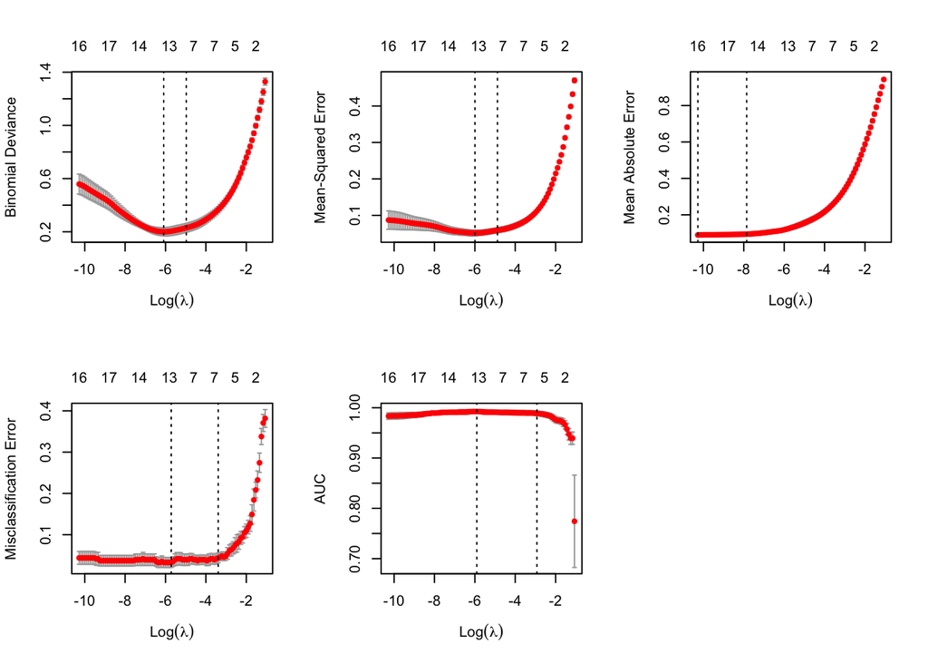

```r
# Use 5-fold cross-validation on training data to find optimal lambda
Y.train = as.vector(dat.train$diagnosis)
#intercept.train = rep(1,nrow(dat.train))
X.train = dat.train[,-1] %>% as.matrix()


registerDoParallel(cores=8)
D.cvfit = cv.glmnet(X.train, Y.train, family = "binomial", nfolds = 5,type.measure = "deviance", parallel=TRUE)
Mse.cvfit = cv.glmnet(X.train, Y.train, family = "binomial", nfolds = 5,type.measure = "mse", parallel=TRUE)
Mae.cvfit = cv.glmnet(X.train, Y.train, family = "binomial", nfolds = 5,type.measure = "mae", parallel=TRUE)
Mis.cvfit = cv.glmnet(X.train, Y.train, family = "binomial", nfolds = 5,type.measure = "class", parallel=TRUE)
ROC.cvfit = cv.glmnet(X.train, Y.train, family = "binomial", nfolds = 5,type.measure = "auc", parallel=TRUE)
stopImplicitCluster()

#Plot
par(mfrow = c(2,3))
plot(D.cvfit)
plot(Mse.cvfit)
plot(Mae.cvfit)
plot(Mis.cvfit)
plot(ROC.cvfit)
```

Using the misclassification error rate, the best lambda is 0.0032887.

```r
opt.lambda <- Mis.cvfit$lambda.min
c<-coef(Mis.cvfit,s='lambda.min',exact=TRUE)
inds<-which(c!=0)
c[inds,] %>% knitr::kable(caption = "Optimal model coefficiants")
```

Optimal model coefficiants

|  | x |
| --- | --- |
| (Intercept) | 0.0536989 |
| area_mean | 2.6998914 |
| texture_se | -0.6741742 |
| area_se | 4.3781569 |
| smoothness_se | -0.0433161 |
| compactness_se | -0.0002808 |
| concave.points_se | 0.6232378 |
| symmetry_se | -0.0201156 |
| fractal_dimension_se | -0.6926414 |
| texture_worst | 1.4892262 |
| smoothness_worst | 1.1064785 |
| compactness_worst | 0.7698568 |
| symmetry_worst | 0.5517947 |
| fractal_dimension_worst | 0.0002283 |

```r
#check the average cross-validated mean squared error when using the one standard error
#Mis.cvfit$cvm[which(Mis.cvfit$lambda==Mis.cvfit$lambda.min)]
```

# Compare the prediction performance of full model and optimal model

```r
# Prediction performance done on test data
Y.test = dat.test$diagnosis
X.test = dat.test[,-1]  %>% as.matrix()

# Fit "optimal" model
opt.model.lasso <- func.logLasso.cd(x = X.test, y = Y.test, beta = rep(0, ncol(X.test)), opt.lambda)
X.test = cbind(rep(1,113),X.test)
X.test = X.test[,inds]

coef = c[inds,] %>% as.vector()
Y.pred = X.test%*%coef %>% exp()
Y.pred = Y.pred/(1+Y.pred)
pred <- ifelse(Y.pred > 0.5, "M", "B")
# Model accuracy
obs <- ifelse(dat.test$diagnosis == 1, "M", "B")
##the optimal model prediction accuracy
 mean(pred == obs)
```

```
## [1] 0.9823009
```

```r
 RSE2 = mean((Y.pred - Y.test)^2)
aRSE2 = RSE2*n/(n-2*15)
performance = data.frame(c(1-mean(pred.classes == obs.classes),1-mean(pred == obs)),c(RSE1,RSE2),c(aRSE1,aRSE2),c(mean(pred.classes == obs.classes), mean(pred == obs)))
colnames(performance) = c("Misclassification Rate","RSE","aRSE","model accurancy")
rownames(performance) = c("Full model","Optimal model")
knitr::kable(performance)
```

|  | Misclassification Rate | RSE | aRSE | model accurancy |
| --- | --- | --- | --- | --- |
| Full model | 0.0530973 | 0.0408531 | 0.0599532 | 0.9469027 |
| Optimal model | 0.0176991 | 0.0185012 | 0.0251884 | 0.9823009 |